# Progetto preliminare programmazione data intensive Albonetti Simone

## Previsione del prezzo di diamanti

`simone.albonetti@studio.unibo.it`

## Setup

- Installare il package opendatasets (nel caso non fosse già presente) per scaricare direttamente il dataset da Kaggle
- Importare le librerie necessarie

```python
#pip install opendatasets
import numpy as np
import pandas as pd
import os.path
import opendatasets as od
import matplotlib.pyplot as plt


from sklearn.exceptions import ConvergenceWarning
from sklearn.linear_model import LinearRegression
from sklearn.model_selection import train_test_split
from sklearn.preprocessing import PolynomialFeatures
from sklearn.metrics import mean_squared_error
from sklearn.preprocessing import StandardScaler
from sklearn.pipeline import Pipeline
from sklearn.metrics import r2_score
from sklearn.preprocessing import OneHotEncoder
from sklearn.compose import ColumnTransformer
from sklearn.linear_model import Lasso
from sklearn.linear_model import Ridge
from sklearn.preprocessing import MinMaxScaler
from sklearn.model_selection import GridSearchCV
from sklearn.model_selection import KFold
from sklearn.linear_model import ElasticNet
from sklearn.tree import DecisionTreeRegressor
from sklearn.tree import plot_tree
from sklearn.ensemble import RandomForestRegressor
from sklearn.model_selection import cross_val_score

import warnings
warnings.simplefilter("ignore", category=ConvergenceWarning)
```

## Predizione del valore dei diamanti

Questo notebook si occupa di determinare il prezzo di un diamante. Questo valore dipende dalle caratteristiche fisiche che possiede.  
Per prima cosa bisogna scaricare il dataset contenente le informazioni sui diamanti.

#### Per scaricare il dataset:

1. Eseguire la cella seguente
2. Inserire il proprio **username** Kaggle
3. Inserire il **token api** Kaggle

```python
if not os.path.exists("/diamonds/diamonds.csv"):
    od.download("https://www.kaggle.com/datasets/shivam2503/diamonds/download?datasetVersionNumber=1")
```

```
Skipping, found downloaded files in ".\diamonds" (use force=True to force download)
```

**Altrimenti** è possibile scaricare manualmente il dataset da questo link: https://www.kaggle.com/datasets/shivam2503/diamonds

Il dataset è sotto forma di file CSV.  
Per leggere questo file usiamo la funzione `read_csv` di Pandas per creare direttamente il dataframe `data` contenente i dati (*utilizziamo la prima colonna come indice per le righe*).

```python
data = pd.read_csv("diamonds/diamonds.csv", index_col=0)
```

### 1a) Descrizione del problema e comprensione dei dati

Il dataset è composto da 53940 istanze. Le feature di ogni diamante sono:

- `carat`: Indica il peso del diamante.
- `cut`: Indica la qualità del taglio.
- `color`: Indica il colore del diamante.
- `clarity`: Indica la purezza del diamante. Cioè quante impurità sono presenti all'interno.
- `x`, `y`, `z`: Indicano le dimensioni del diamante (lunghezza, larghezza e profondità) in **mm**
- `depth`: Questa proprietà è chiamata **total depth percentage** e indica se il diamante è *sotto peso* oppure *sopra peso*. E' un dato derivabile infatti per calcolarlo la formula è **2 * z / ( x + y)** , quindi **ATTENZIONE ALLA COLLINEARITA'**
- `table`: Indica la dimensione della superficie piatta che si trova sopra al diamante.
- `price`: Indica il prezzo in **dollari** del diamante. Questa è la **VARIABILE DA PREDIRE** in funzione delle altre.

Poichè `price` è una variabile **continua** si tratta di un problema di *Regressione* (*multivariata* perchè dipende da più di una feature)

```python
data.head()
```

|  | carat | cut | color | clarity | depth | table | price | x | y | z |
| --- | --- | --- | --- | --- | --- | --- | --- | --- | --- | --- |
| 1 | 0.23 | Ideal | E | SI2 | 61.5 | 55.0 | 326 | 3.95 | 3.98 | 2.43 |
| 2 | 0.21 | Premium | E | SI1 | 59.8 | 61.0 | 326 | 3.89 | 3.84 | 2.31 |
| 3 | 0.23 | Good | E | VS1 | 56.9 | 65.0 | 327 | 4.05 | 4.07 | 2.31 |
| 4 | 0.29 | Premium | I | VS2 | 62.4 | 58.0 | 334 | 4.20 | 4.23 | 2.63 |
| 5 | 0.31 | Good | J | SI2 | 63.3 | 58.0 | 335 | 4.34 | 4.35 | 2.75 |

### 1b) Analisi esplorativa dei dati

```python
data.info()
```

```
<class 'pandas.core.frame.DataFrame'>
Int64Index: 53940 entries, 1 to 53940
Data columns (total 10 columns):
 #   Column   Non-Null Count  Dtype
---  ------   --------------  -----
 0   carat    53940 non-null  float64
 1   cut      53940 non-null  object
 2   color    53940 non-null  object
 3   clarity  53940 non-null  object
 4   depth    53940 non-null  float64
 5   table    53940 non-null  float64
 6   price    53940 non-null  int64
 7   x        53940 non-null  float64
 8   y        53940 non-null  float64
 9   z        53940 non-null  float64
dtypes: float64(6), int64(1), object(3)
memory usage: 4.5+ MB
```

#### Variabili CATEGORICHE

Alcune feature sono categoriche (`cut`, `color` e `clarity`), quindi le dichiariamo di tipo `category` (andando anche a ridurre lo spazio del dataset).

```python
custom_dtypes = {
    "cut" : "category",
    "color" : "category",
    "clarity" : "category"
}

categorical_var = ["cut", "color", "clarity"]
numerical_var = ["carat", "table", "price", "x", "y", "z" ]
numerical_var_not_price = numerical_var.copy()
numerical_var_not_price.remove("price")

data = pd.read_csv("diamonds/diamonds.csv", index_col=0, dtype=custom_dtypes)
```

```python
data.info()
```

```
<class 'pandas.core.frame.DataFrame'>
Int64Index: 53940 entries, 1 to 53940
Data columns (total 10 columns):
 #   Column   Non-Null Count  Dtype
---  ------   --------------  -----
 0   carat    53940 non-null  float64
 1   cut      53940 non-null  category
 2   color    53940 non-null  category
 3   clarity  53940 non-null  category
 4   depth    53940 non-null  float64
 5   table    53940 non-null  float64
 6   price    53940 non-null  int64
 7   x        53940 non-null  float64
 8   y        53940 non-null  float64
 9   z        53940 non-null  float64
dtypes: category(3), float64(6), int64(1)
memory usage: 3.4 MB
```

I possibili valori delle variabili categoriche sono:

```python
print("data['cut']:" , data["cut"].unique(), "\n")
print("data['color']:" , data["color"].unique(), "\n")
print("data['clarity']:" , data["clarity"].unique())
```

```
data['cut']: ['Ideal', 'Premium', 'Good', 'Very Good', 'Fair']
Categories (5, object): ['Fair', 'Good', 'Ideal', 'Premium', 'Very Good']

data['color']: ['E', 'I', 'J', 'H', 'F', 'G', 'D']
Categories (7, object): ['D', 'E', 'F', 'G', 'H', 'I', 'J']

data['clarity']: ['SI2', 'SI1', 'VS1', 'VS2', 'VVS2', 'VVS1', 'I1', 'IF']
Categories (8, object): ['I1', 'IF', 'SI1', 'SI2', 'VS1', 'VS2', 'VVS1', 'VVS2']
```

Le distribuzioni delle feature categoriche sono le seguenti (**normalizzate**):

```
Ideal        39.953652
Premium      25.567297
Very Good    22.398962
Good          9.095291
Fair          2.984798
Name: cut, dtype: float64
```

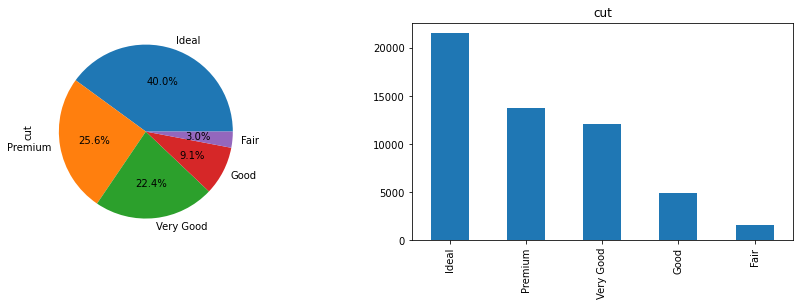

```python
print(data["cut"].value_counts(normalize=True) * 100)

plt.figure(figsize=(15, 4))
data["cut"].value_counts(normalize=True).plot.pie(autopct='%1.1f%%', ax=plt.subplot(1,2,1))
data["cut"].value_counts().plot.bar(ax=plt.subplot(1, 2, 2), title = "cut")
```

```
G    20.934372
E    18.162773
F    17.690026
H    15.394883
D    12.560252
I    10.051910
J     5.205784
Name: color, dtype: float64
```

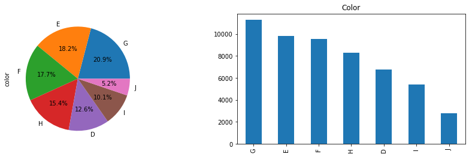

```python
print(data["color"].value_counts(normalize=True) * 100)
plt.figure(figsize=(15, 4))
data["color"].value_counts(normalize=True).plot.pie(autopct='%1.1f%%', ax=plt.subplot(1,2,1))
data["color"].value_counts().plot.bar(ax=plt.subplot(1, 2, 2), title = "Color")
```

```
SI1     24.221357
VS2     22.725250
SI2     17.044865
VS1     15.148313
VVS2     9.391917
VVS1     6.776047
IF       3.318502
I1       1.373749
Name: clarity, dtype: float64
```

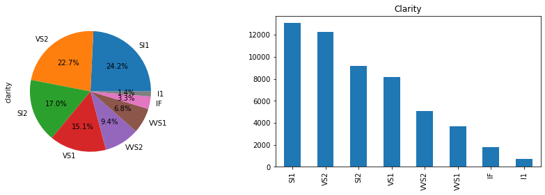

```python
print(data["clarity"].value_counts(normalize=True) * 100)
plt.figure(figsize=(15, 4))
data["clarity"].value_counts(normalize=True).plot.pie(autopct='%1.1f%%', ax=plt.subplot(1,2,1))
data["clarity"].value_counts().plot.bar(ax=plt.subplot(1, 2, 2), title = "Clarity")
```

Dopo aver visto le distribuzioni delle variabili categoriche controlliamo se ci sono eventuali correlazioni tra queste variabili e `price`.

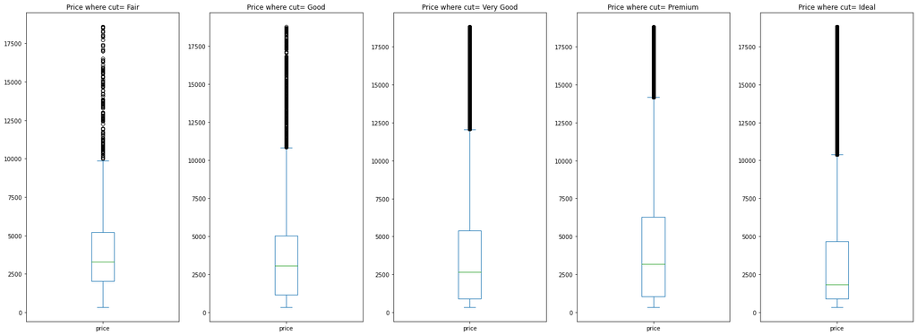

```python
plt.figure(figsize=(28, 10))
for index, value in enumerate(["Fair", "Good", "Very Good", "Premium", "Ideal"], start=1):
    data[data["cut"] == value]["price"].plot.box(ax=plt.subplot(1,5,index), title=("Price where cut= "+ str(value)))
```

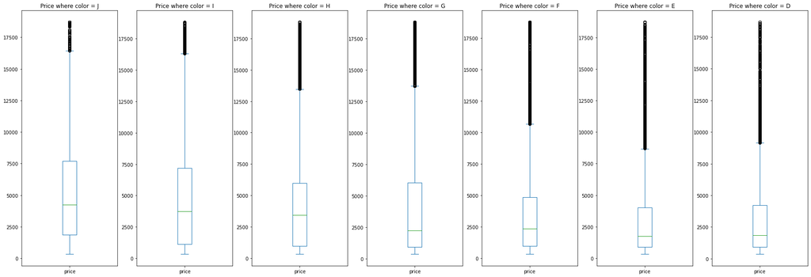

```python
plt.figure(figsize=(30,10))
for index,value in enumerate(sorted(data["color"].unique(), reverse=True), start=1):
    data[data["color"] == value]["price"].plot.box(ax=plt.subplot(1,7,index), title=("Price where color = "+ str(value)))
```

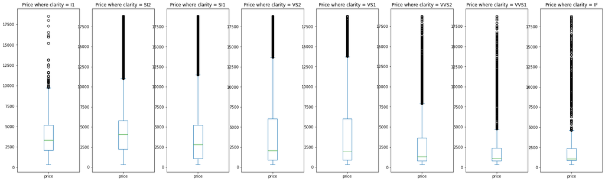

```python
plt.figure(figsize=(28, 8))
for index, value in enumerate(["I1", "SI2", "SI1", "VS2", "VS1", "VVS2", "VVS1", "IF"], start=1):
    data[data["clarity"] == value]["price"].plot.box(ax=plt.subplot(1,8,index), title=("Price where clarity = "+ str(value)))
```

Infatti andando a creare delle "categorie" fittizie (in realtà sono stati creati degli intervalli nella variabile `carat` per simulare delle categorie), si nota che la scala di valore di `price` cambia da categoria a categoria.

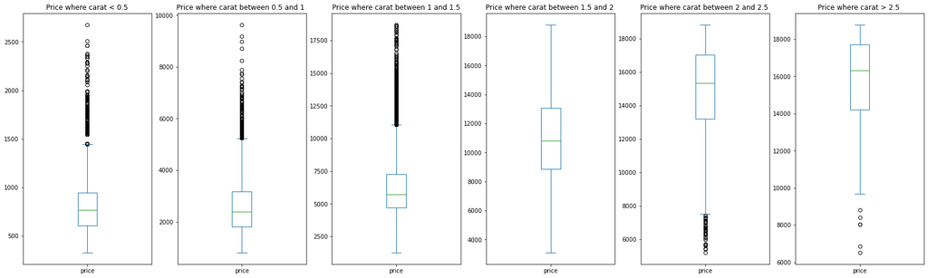

```python
plt.figure(figsize=(28, 8))
data[data["carat"] < 0.5]["price"].plot.box(ax=plt.subplot(1,6,1), title=("Price where carat < "+ str(0.5)))
data[(data["carat"] < 1) & (data["carat"] > 0.5)]["price"].plot.box(ax=plt.subplot(1,6,2), title=("Price where carat between 0.5 and 1 "))
data[(data["carat"] < 1.5) & (data["carat"] > 1)]["price"].plot.box(ax=plt.subplot(1,6,3), title=("Price where carat between 1 and 1.5"))
data[(data["carat"] < 2) & (data["carat"] > 1.5)]["price"].plot.box(ax=plt.subplot(1,6,4), title=("Price where carat between 1.5 and 2 "))
data[(data["carat"] < 2.5) & (data["carat"] > 2)]["price"].plot.box(ax=plt.subplot(1,6,5), title=("Price where carat between 2 and 2.5 "))
data[data["carat"] > 2.5]["price"].plot.box(ax=plt.subplot(1,6,6), title=("Price where carat > 2.5 "))
```

#### Variabili CONTINUE

```python
data.describe()
```

|  | carat | depth | table | price | x | y | z |
| --- | --- | --- | --- | --- | --- | --- | --- |
| count | 53940.000000 | 53940.000000 | 53940.000000 | 53940.000000 | 53940.000000 | 53940.000000 | 53940.000000 |
| mean | 0.797940 | 61.749405 | 57.457184 | 3932.799722 | 5.731157 | 5.734526 | 3.538734 |
| std | 0.474011 | 1.432621 | 2.234491 | 3989.439738 | 1.121761 | 1.142135 | 0.705699 |
| min | 0.200000 | 43.000000 | 43.000000 | 326.000000 | 0.000000 | 0.000000 | 0.000000 |
| 25% | 0.400000 | 61.000000 | 56.000000 | 950.000000 | 4.710000 | 4.720000 | 2.910000 |
| 50% | 0.700000 | 61.800000 | 57.000000 | 2401.000000 | 5.700000 | 5.710000 | 3.530000 |
| 75% | 1.040000 | 62.500000 | 59.000000 | 5324.250000 | 6.540000 | 6.540000 | 4.040000 |
| max | 5.010000 | 79.000000 | 95.000000 | 18823.000000 | 10.740000 | 58.900000 | 31.800000 |

Però ci sono alcuni diamanti che sono senza dimensioni (perchè il min di `x`, `y`, e `z` è 0). Per questo motivo bisogna **eliminare le istanze che non hanno dimensioni**.

I grafici seguenti mostrano le distribuzioni delle variabili continue (`carat`, `depth`, `table`, `x`, `y` e `z`).

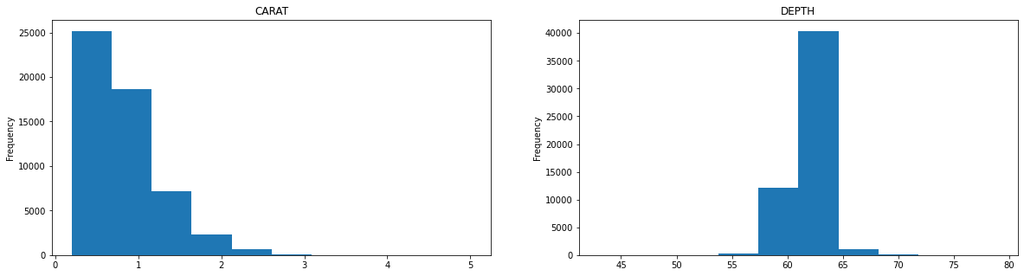

```python
plt.figure(figsize=(20, 5))
for n, col in enumerate(["carat", "depth"], start=1):
    data[col].plot.hist(ax=plt.subplot(1, 2, n), title = col.upper())
```

- **`carat`**: Il valore massimo è 5.01, ma valori superiori a 1 sono meno comuni
- **`depth`**: In questo caso abbiamo una grossa distribuzione di valori tra 60 e 63, mentre gli altri valori sono poco comuni.

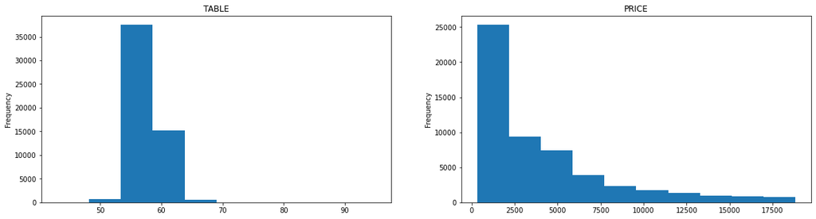

```python
plt.figure(figsize=(20, 5))
for n, col in enumerate(["table", "price"], start=1):
    data[col].plot.hist(ax=plt.subplot(1, 2, n), title = col.upper())
```

- **`table`**: Come per la `depth` anche qui abbiamo una grossa distribuzione di valori intorno al 57, mentre altri valori sono meno comuni.
- **`price`**: Il suo valore massimo è 18823, ma la maggior parte dei valori si trova tra 0 e 2500, valori maggiori sono meno comuni.

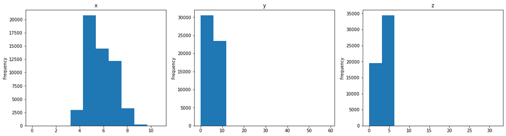

```python
plt.figure(figsize=(20, 5))
for n, col in enumerate(["x", "y", "z"], start=1):
    data[col].plot.hist(ax=plt.subplot(1, 3, n), title = col)
```

- **`x`** , **`y`** , **`z`** : Le distribuzioni delle dimensioni sono abbastanza simili ed omogenee a parte per qualche istanza che ha valori di altezza e profondità (`y` e `z`) molto elevati (**outlier**).

Nella cella seguenti sono presenti dei *box plot* per evidenziare tutti gli **outlier** di tutte le variabili continue.

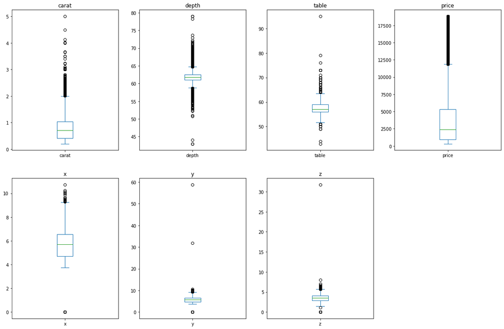

```python
plt.figure(figsize=(20, 20))
for n, col in enumerate(["carat", "depth", "table", "price", "x", "y", "z"], start=1):
    data[col].plot.box(ax=plt.subplot(3, 4, n), title = col)
```

Si vede chiaramente che nelle variabili `depth`, `table`, `y` e `z` ci sono degli **outlier** che hanno valori molto distanti dai valori "ordinari".  
Quindi andranno eliminati.

### 2) Preparazione dei dati

- Eliminiamo quelle istanze che hanno 1 o più dimensioni uguale a 0

```python
data.drop(data[data['x'] == 0].index, inplace=True)
data.drop(data[data['y'] == 0].index, inplace=True)
data.drop(data[data['z'] == 0].index, inplace=True)
print(data.shape)
```

```
(53920, 10)
```

Il numero di istanze è passato a 53920

- Eliminiamo le istanze che sono delgli outlier per le variabili `depth`,`table`,`y` e `z`

```python
data.drop(data[data["depth"] > 75].index, inplace=True)
data.drop(data[data["depth"] < 45].index, inplace=True)
data.drop(data[data["table"] > 75].index, inplace=True)
data.drop(data[data["table"] < 45].index, inplace=True)
data.drop(data[data["y"] > 15].index, inplace=True)
data.drop(data[data["z"] > 10].index, inplace=True)
data.drop(data[data["z"] < 2].index, inplace=True)
print(data.shape)
```

```
(53903, 10)
```

Ora il numero di istanze è 53903, e come si può vedere dai grafici seguenti, gli *outlier rimasti sono meno distanti/significativi*.

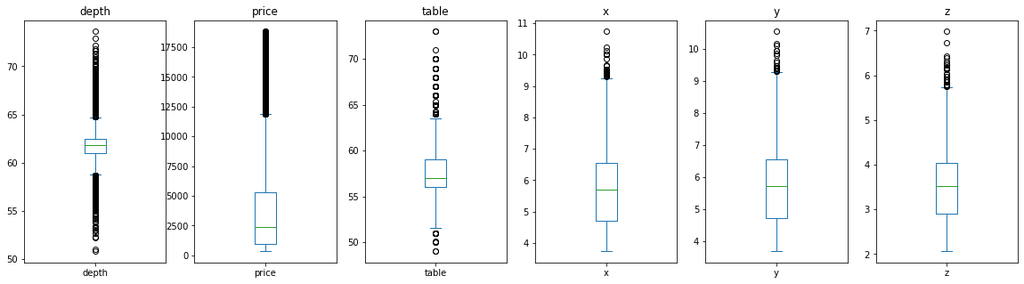

```python
plt.figure(figsize=(20, 5))
for n, col in enumerate(["depth","price", "table", "x", "y", "z"], start=1):
    data[col].plot.box(ax=plt.subplot(1, 6, n), title = col)
```

Mostriamo attraverso un grafico a dispersione le varie correlazioni con la variabile `price`.

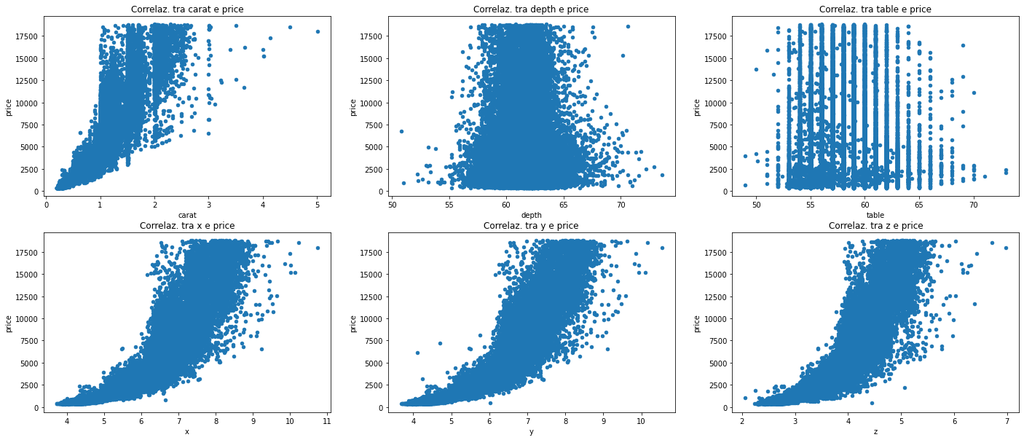

```python
plt.figure(figsize=(24, 10))
for n, col in enumerate(["carat", "depth", "table", "x", "y", "z"], start=1):
    data.plot.scatter(col, "price", ax=plt.subplot(2, 3, n), title = "Correlaz. tra " + col + " e price")
```

`depth` e `table` non mostrano una correlazione con `price`, mentre le dimensioni `x`, `y`, `z` e `carat` sembrano avere una relazione con `price`.

Inoltre, `depth` è una variabile dipendente e derivabile da `x`, `y` e `z`. Quindi per non generare *collinearità* **NON VERRA' PRESA IN CONSIDERAZIONE**

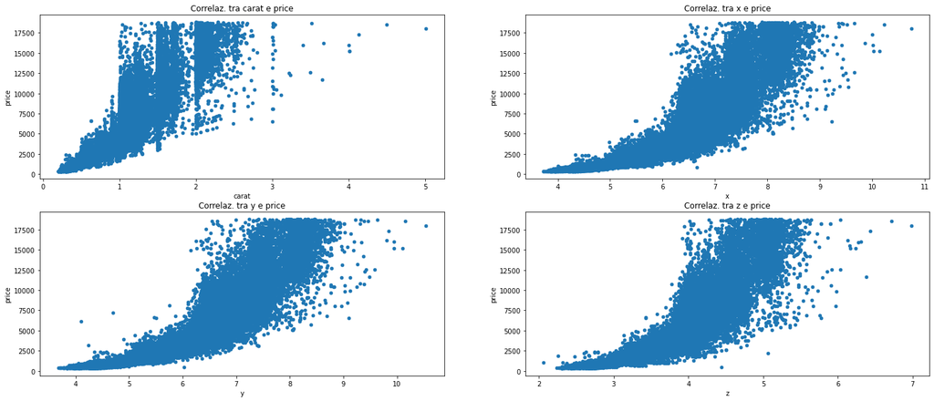

```python
plt.figure(figsize=(24, 10))
for n, col in enumerate(["carat", "x", "y", "z"], start=1):
    data.plot.scatter(col, "price", ax=plt.subplot(2, 2, n), title = "Correlaz. tra " + col + " e price")
```

Per determinare quali siano le feature più rilevanti, andremo a utilizzare la regressione **`Lasso`**, che andrà ad eliminare le feature meno significative.

All'inizio inseriremo tutte le feature all'interno del modello, quindi useremo:

- `OneHotEncoder` per binarizzare le variabili categoriche
- `MinMaxScaler` per normalizzare le variabili numeriche

Utilizziamo una `Pipeline` per eseguire tute queste operazioni e anche un `ColumnTransformer` per poter applicare l'`OneHotEncoder` e il `MinMaxScaler` solo alle colonne scelte (passate come argomenti).

Per prima cosa generiamo i 4 set necessari all'addestramento e alla validazione del modello (`x_complete_train`, `x_complete_val`, `y_complete_train` e `y_coplete_val`).

```python
x_complete = data.drop(columns=["price", "depth"])
y_complete = data["price"]

x_complete_train, x_complete_val, y_complete_train, y_complete_val = train_test_split(x_complete, y_complete, test_size=1/3, random_state=42)
```

Serviranno nel punto 3), quando faremo le valutazioni degli algoritmi

```python
models_mse = {}
models_re = {}
models_r2 = {}
models_rmspe = {}
models_hyperparameter = {}
models_feature_coeff = {}

# Contiene lo scarto quadratico medio e la deviazione standard dell'errore degli iperparametri di ciascun modello
# ottenuti in k cross fold validation
models_result_gs_kf = {}
```

Creiamo una funzione come quella usata nei laboratori per determinare l'efficacia dei modelli.

```python
def relative_error(y_true, y_pred):
    return np.mean(np.abs((y_true - y_pred) / y_true))

def rmspe(y_real, y_pred):
    return np.sqrt(np.mean((y_pred /y_real - 1) ** 2))

def print_eval(X, y, model, name_for_dictionary=1, hyperparameter=None, coeff=None):
    y_pred = model.predict(X)
    mse = mean_squared_error(y, y_pred)
    re = relative_error(y,y_pred)
    r2 = r2_score(y, y_pred)
    rmsp = rmspe(y, y_pred)
    print(f"           MSE: {mse:12.4f}")
    print(f"Relative error: {re:12.4f}")
    print(f"     R-squared: {r2:12.4f}")
    print(f"         RMSPE: {rmsp:12.4f}")

    #SE abbiamo fornito un nome del nostro modello, possiamo salvare le valutazioni del modello nei dicionary
    if(name_for_dictionary != 1):
        models_mse[name_for_dictionary] = mse
        models_re[name_for_dictionary] = re
        models_r2[name_for_dictionary] = r2
        models_rmspe[name_for_dictionary] = rmsp

        #SE abbiamo fornito gli iperparametri li salviamo nel dictionary models_hyperparameter
        if(hyperparameter is not None):
            models_hyperparameter[name_for_dictionary] = hyperparameter

        #SE abbiamo fornito i coefficenti delle feature le salviamo nel dictionary models_feature_coef
        if(coeff is not None):
            models_feature_coeff[name_for_dictionary] = coeff
```

Addestriamo il primo modello (quello contenente tutte le feature).

```python
model_complete = Pipeline ([
    ("preproc", ColumnTransformer([
        ("numeric", MinMaxScaler(), numerical_var_not_price),
        ("categorical", OneHotEncoder(), categorical_var)
    ])),
    ("regr", Lasso(alpha=1))
    ])
model_complete.fit(x_complete_train, y_complete_train)
```

```
Pipeline(steps=[('preproc',
                 ColumnTransformer(transformers=[('numeric', MinMaxScaler(),
                                                  ['carat', 'table', 'x', 'y',
                                                   'z']),
                                                 ('categorical',
                                                  OneHotEncoder(),
                                                  ['cut', 'color',
                                                   'clarity'])])),
                ('regr', Lasso(alpha=1))])
```

Mostriamo le **feature più rilevanti** con i rispettivi **coefficenti**

```python
print(pd.Series(model_complete.named_steps["regr"].coef_, model_complete.named_steps["preproc"].get_feature_names_out()).sort_values(ascending=False))
print("Feature utilizzate: ",(model_complete.named_steps["regr"].coef_ !=0).sum())
```

```
numeric__carat                46825.083262
categorical__clarity_IF         983.201132
categorical__clarity_VVS1       614.111897
categorical__clarity_VVS2       587.147167
categorical__color_D            457.364503
categorical__color_E            243.412674
categorical__clarity_VS1        210.308099
categorical__color_F            199.134502
categorical__cut_Ideal          117.012519
numeric__y                       -0.000000
categorical__cut_Premium          0.000000
categorical__cut_Very Good        0.000000
categorical__color_G              0.000000
categorical__clarity_VS2        -84.629783
categorical__cut_Good          -159.730673
numeric__table                 -489.765089
categorical__color_H           -492.660063
categorical__clarity_SI1       -702.360420
categorical__cut_Fair          -742.732037
categorical__color_I           -964.249314
categorical__clarity_SI2      -1645.118731
categorical__color_J          -1871.665560
numeric__x                    -1956.125251
categorical__clarity_I1       -4297.157739
numeric__z                    -4383.003806
dtype: float64
Feature utilizzate:  21
```

Lo **score** del modello è il seguente:

```python
print_eval(x_complete_val, y_complete_val, model_complete)
```

```
           MSE: 1294466.5914
Relative error:       0.3900
     R-squared:       0.9173
         RMSPE:       0.7516
```

Il modello con tutte le feature, utilizza 21 variabili (sono più di quelle iniziali perchè con l'`OneHotEncoder` viene generata una variabile binaria per ogni possibile valore di ogni variabile categorica).

Ha un errore relativo abbastanza alto (39%) ma anche un R-squared molto alto.

Proviamo ora ad utilizzare **solo le 4 feature** (`carat`, `x`, `y` e `z`) che secondo i grafici avevano una correlazione con `price`.

```python
x = data.drop(columns=["cut", "color", "clarity", "depth", "table", "price"])
y = data["price"]

x_train, x_val, y_train, y_val = train_test_split(x, y, test_size=1/3, random_state=42)
x_train.columns
```

```
Index(['carat', 'x', 'y', 'z'], dtype='object')
```

Creiamo un modello semplificato `model_simple` che non tiene conto delle variabili categoriche (quindi non serve l'`OneHotEncoder`), di `depth` e di `table`.

```python
model_simple = Pipeline ([
    ("numeric", MinMaxScaler()),
    ("regr", Lasso(alpha=1))
])
model_simple.fit(x_train, y_train)
```

```
Pipeline(steps=[('numeric', MinMaxScaler()), ('regr', Lasso(alpha=1))])
```

Questi sono i coefficenti delle feature più rilevanti.

```python
print(pd.Series(model_simple.named_steps["regr"].coef_, x.columns).sort_values(ascending=False))
print("Feature utilizzate: ",(model_simple.named_steps["regr"].coef_ !=0).sum())
```

```
carat    44078.243632
y          434.027298
x           -0.000000
z        -8675.797090
dtype: float64
Feature utilizzate:  3
```

```python
print_eval(x_val, y_val, model_simple)
```

```
           MSE: 2298602.8214
Relative error:       0.2747
     R-squared:       0.8531
         RMSPE:       0.3550
```

Proviamo a utilizzare solo le **4 feature iniziali** e a generare alcune **feature polinomiali derivate**, attraverso l'uso di `PolynomialFeatures`.

```python
model_poly = Pipeline ([
    ("poly", PolynomialFeatures(degree=4, include_bias=False)),
    ("numeric", MinMaxScaler()),
    ("regr", Lasso(alpha=1))
])
model_poly.fit(x_train, y_train)
```

```
Pipeline(steps=[('poly', PolynomialFeatures(degree=4, include_bias=False)),
                ('numeric', MinMaxScaler()), ('regr', Lasso(alpha=1))])
```

```python
print(pd.Series(model_poly.named_steps["regr"].coef_, model_poly.named_steps["poly"].get_feature_names_out(x.columns)).sort_values(ascending=False))
print("Feature utilizzate: ",(model_poly.named_steps["regr"].coef_ !=0).sum())
```

```
y^3          12898.264779
x y^2        10311.044421
y^4           8287.427208
carat y       5185.540643
x y z         4467.983320
                 ...
z^3              0.000000
carat^3 y       -0.000000
carat^3 x   -10163.493510
x           -11216.052867
carat^4     -14454.527851
Length: 69, dtype: float64
Feature utilizzate:  14
```

Con il `PolynomialFeatures` vengono create delle variabili polinomiali e in questo modo si usano **14 feature**.

```python
print_eval(x_val, y_val, model_poly)
```

```
           MSE: 2058049.7634
Relative error:       0.2390
     R-squared:       0.8685
         RMSPE:       0.3078
```

Nella cella seguente sono mostrati i risultati dei 3 modelli per fare un confronto.

```python
print("Modello completo con tutte le feature:")
print_eval(x_complete_val, y_complete_val, model_complete)

print("\nModello con solo 4 feature (carat, x, y, z):")
print_eval(x_val, y_val, model_simple)

print("\nModello con 4 feature + feature polinomiali:")
print_eval(x_val, y_val, model_poly)
```

```
Modello completo con tutte le feature:
           MSE: 1294466.5914
Relative error:       0.3900
     R-squared:       0.9173
         RMSPE:       0.7516

Modello con solo 4 feature (carat, x, y, z):
           MSE: 2298602.8214
Relative error:       0.2747
     R-squared:       0.8531
         RMSPE:       0.3550

Modello con 4 feature + feature polinomiali:
           MSE: 2058049.7634
Relative error:       0.2390
     R-squared:       0.8685
         RMSPE:       0.3078
```

Visti i risultati, per il punto 3) useremo le seguenti feature:

- `carat`
- `x`
- `y`
- `z`
- Eventuali feature polinomiali generate con il `PolinomialFeatures`

### 3) Generazione dei modelli

Utilizzeremo la grid search (`GridSearchCV`) per determinare i migliori iperparametri del modello finale.

Inoltre utilizzeremo la K-Fold Cross Validation (`KFold`) per valutare in modo più preciso l'accuratezza dei modelli.

Quindi creiamo un oggetto `KFold` a 7 fold.

```python
kf = KFold(7, shuffle=True, random_state=42)
```

Prima riprendiamo i dati che ci servono

```python
x = data.drop(columns=["cut", "color", "clarity", "depth", "table", "price"])
y = data["price"]

x_train, x_val, y_train, y_val = train_test_split(x, y, test_size=1/3, random_state=42)
```

Creiamo una funzione che:

- Addestra i modelli
- Mostra i migliori parametri ottenuti dalla `GridSearch`
- Calcola la media e la deviazione standard degli score ottenuti
- Inserisce i migliori parametri e le feature usate nei dictionary creati in precedenza

```python
def grid_test(model, grid, model_name=1):
    gs = GridSearchCV(model, grid, cv=kf, verbose=0)
    gs.fit(x_train, y_train)
    print(gs.best_params_)

    score = cross_val_score(model, x_val, y_val)
    mean = score.mean()
    std = score.std()

    if model_name != 1:
        models_result_gs_kf[model_name] = pd.DataFrame(data={"Media": mean, "Deviazione standard": std},
                                                       index=[model_name])

    features_coeff = pd.Series(gs.best_estimator_.named_steps["reg"].coef_,
                                  gs.best_estimator_.named_steps["poly"].get_feature_names_out()).sort_values(ascending=False)
    print_eval(x_val, y_val, gs, model_name, gs.best_params_, features_coeff)
```

Ora procediamo a creare diversi modelli, **uno per ogni algoritmo di regressione**.

#### LinearRegression

```python
model_linear = Pipeline([
    ("scaler", None),
    ("poly", PolynomialFeatures(include_bias=False)),
    ("reg", LinearRegression())
])

grid_linear = {
    "scaler": [None, MinMaxScaler(), StandardScaler()],
    "poly__degree": [1,2,4]
}

%time grid_test(model_linear, grid_linear, "LinearRegression")
models_result_gs_kf["LinearRegression"]
```

```
{'poly__degree': 2, 'scaler': None}
           MSE: 1967546.2722
Relative error:       0.2136
     R-squared:       0.8743
         RMSPE:       0.2832
CPU times: total: 7.67 s
Wall time: 1.93 s
```

|  | Media | Deviazione standard |
| --- | --- | --- |
| LinearRegression | 0.869846 | 0.00826 |

#### Regressione Ridge

```python
model_ridge = Pipeline([
    ("scaler", None),
    ("poly", PolynomialFeatures(include_bias=False)),
    ("reg", Ridge())
])

grid_ridge = {
    "scaler": [None, MinMaxScaler(), StandardScaler()],
    "poly__degree": [1,2,4],
    "reg__alpha": [0.01, 0.1, 1]
}

%time grid_test(model_ridge, grid_ridge, "Ridge regression")
models_result_gs_kf["Ridge regression"]
```

```
{'poly__degree': 4, 'reg__alpha': 0.01, 'scaler': MinMaxScaler()}
           MSE: 1902322.5710
Relative error:       0.2105
     R-squared:       0.8784
         RMSPE:       0.2767
CPU times: total: 13.9 s
Wall time: 3.49 s
```

|  | Media | Deviazione standard |
| --- | --- | --- |
| Ridge regression | 0.871162 | 0.004724 |

```python
warnings.filterwarnings(action='ignore', category=ConvergenceWarning)
```

#### Regressione Lasso

```python
model_lasso = Pipeline([
    ("scaler", None),
    ("poly", PolynomialFeatures(include_bias=False)),
    ("reg", Lasso())
])

grid_lasso = {
    "scaler": [None, MinMaxScaler(), StandardScaler()],
    "poly__degree": [1,2,4],
    "reg__alpha": [0.01, 0.1, 1]
}

%time grid_test(model_lasso, grid_lasso, "Lasso regression")

models_result_gs_kf["Lasso regression"]
```

```
{'poly__degree': 4, 'reg__alpha': 0.01, 'scaler': MinMaxScaler()}
           MSE: 1930497.0935
Relative error:       0.2221
     R-squared:       0.8766
         RMSPE:       0.2944
CPU times: total: 4min 2s
Wall time: 1min
```

|  | Media | Deviazione standard |
| --- | --- | --- |
| Lasso regression | 0.868718 | 0.005115 |

#### Elastic Net

```python
model_elastic = Pipeline([
    ("scaler", None),
    ("poly", PolynomialFeatures(include_bias=False)),
    ("reg", ElasticNet())
])

grid_elastic = {
    "scaler": [None, MinMaxScaler(), StandardScaler()],
    "poly__degree": [1,2,4],
    "reg__alpha": [0.1, 1, 10],
    "reg__l1_ratio": [0.1, 0.25, 0.5]
}

%time grid_test(model_elastic, grid_elastic, "Elastic net")

models_result_gs_kf["Lasso regression"]
```

```
{'poly__degree': 4, 'reg__alpha': 0.1, 'reg__l1_ratio': 0.5, 'scaler': StandardScaler()}
           MSE: 1956882.2280
Relative error:       0.2203
     R-squared:       0.8750
         RMSPE:       0.2937
CPU times: total: 8min 58s
Wall time: 2min 15s
```

|  | Media | Deviazione standard |
| --- | --- | --- |
| Lasso regression | 0.868718 | 0.005115 |

I risultati ottenuti fin'ora sono molto simili, la combinazione migliore è quella che usa la **Regression Ridge** con i parametri:

- Grado di `PolynomialFeatures` = 4,
- Grado alpha = 0.01
- MinMaxScaler()

I risultati sono: MSE: 1902322.5710  
Relative error: 0.2105  
R-squared: 0.8784  
RMSPE: 0.2767

#### Decision tree

```python
model_tree = DecisionTreeRegressor(max_depth=10, random_state=42)
%time model_tree.fit(x_train, y_train)
```

```
CPU times: total: 250 ms
Wall time: 53.3 ms
```

```
DecisionTreeRegressor(max_depth=10, random_state=42)
```

Nel `DecisionTreeRegressor` i coefficenti delle feature sono le seguenti:

```python
print(pd.Series(model_tree.feature_importances_, x_train.columns).sort_values(ascending=False),
      "\nDepth: ", model_tree.get_depth(),
      "\nLeaves: ", model_tree.get_n_leaves())
```

```
carat    0.730579
y        0.255306
z        0.009114
x        0.005001
dtype: float64
Depth:  10
Leaves:  800
```

Per quanto riguarde le prestazioni, sono praticamente uguali a quelle della **Regressione Ridge**

```python
print_eval(x_val, y_val, model_tree, "Decision tree")
models_feature_coeff["Decision tree"] = pd.Series(model_tree.feature_importances_, x_train.columns).sort_values(ascending=False)
models_hyperparameter["Decision tree"] = model_tree.get_params()

score = cross_val_score(model_tree, x_val, y_val, cv=kf)
mean = score.mean()
std = score.std()
models_result_gs_kf["Decision tree"] = pd.DataFrame(data={"Media":mean, "Deviazione standard": std}, index=["Decision tree"])
models_result_gs_kf["Decision tree"]
```

```
           MSE: 2019954.7575
Relative error:       0.2026
     R-squared:       0.8709
         RMSPE:       0.2711
```

|  | Media | Deviazione standard |
| --- | --- | --- |
| Decision tree | 0.862788 | 0.006625 |

#### Random forest

```python
model_random_forest = RandomForestRegressor(max_samples=0.1, max_features="sqrt", n_estimators=600, max_depth=None, n_jobs=-1)
%time model_random_forest.fit(x_train, y_train)
```

```
CPU times: total: 7.5 s
Wall time: 1.39 s
```

```
RandomForestRegressor(max_features='sqrt', max_samples=0.1, n_estimators=600,
                      n_jobs=-1)
```

```python
print_eval(x_val, y_val, model_random_forest, "Random forest")
models_feature_coeff["Random forest"] = pd.Series(model_random_forest.feature_importances_, x_train.columns).sort_values(ascending=False)
models_hyperparameter["Random forest"] = model_random_forest.get_params()

mean = cross_val_score(model_random_forest, x_val, y_val, cv=kf).mean()
std = cross_val_score(model_random_forest, x_val, y_val, cv=kf).std()
models_result_gs_kf["Random forest"] = pd.DataFrame(data={"Media":mean, "Deviazione standard": std}, index=["Random forest"])
models_result_gs_kf["Random forest"]
```

```
           MSE: 1828117.8697
Relative error:       0.1989
     R-squared:       0.8832
         RMSPE:       0.2643
```

|  | Media | Deviazione standard |
| --- | --- | --- |
| Random forest | 0.8809 | 0.004383 |

Con il **`RandomForestRegressor` abbiamo avuto i migliori risultati fin'ora.**

Nella cella presente vengono mostrati i coefficenti delle feature usate.

```python
pd.Series(model_random_forest.feature_importances_, model_random_forest.feature_names_in_).sort_values(ascending=False)
```

```
y        0.399008
carat    0.320091
x        0.212491
z        0.068410
dtype: float64
```

#### Random forest (usando tutte le variabili, anche quelle categoriche)

Proviamo ad usare il `RandomForestRegressor` con tutte le variabili (anche quelle categoriche).

```python
model_random_forest_complete = Pipeline ([
    ("preproc", ColumnTransformer([
        ("numeric", MinMaxScaler(), numerical_var_not_price),
        ("categorical", OneHotEncoder(), categorical_var)
    ])),
    ("reg", RandomForestRegressor(max_samples=0.1, max_features="sqrt", n_estimators=600, max_depth=None, n_jobs=-1))
    ])
%time model_random_forest_complete.fit(x_complete_train, y_complete_train)
```

```
CPU times: total: 7.31 s
Wall time: 1.57 s
```

```
Pipeline(steps=[('preproc',
                 ColumnTransformer(transformers=[('numeric', MinMaxScaler(),
                                                  ['carat', 'table', 'x', 'y',
                                                   'z']),
                                                 ('categorical',
                                                  OneHotEncoder(),
                                                  ['cut', 'color',
                                                   'clarity'])])),
                ('reg',
                 RandomForestRegressor(max_features='sqrt', max_samples=0.1,
                                       n_estimators=600, n_jobs=-1))])
```

```python
print_eval(x_complete_val, y_complete_val, model_random_forest_complete, "Random forest complete")
models_feature_coeff["Random forest complete"] = pd.Series(model_random_forest_complete.named_steps["reg"].feature_importances_,
                                                          model_random_forest_complete.named_steps["preproc"].get_feature_names_out()).sort_values(ascending=False)
models_hyperparameter["Random forest complete"] = model_random_forest_complete.named_steps["reg"].get_params()

mean = cross_val_score(model_random_forest_complete, x_complete_val, y_complete_val, cv=kf).mean()
std = cross_val_score(model_random_forest_complete, x_complete_val, y_complete_val, cv=kf).std()
models_result_gs_kf["Random forest complete"] = pd.DataFrame(data={"Media":mean, "Deviazione standard": std}, index=["Random forest complete"])
models_result_gs_kf["Random forest complete"]
```

```
           MSE:  497621.0423
Relative error:       0.0945
     R-squared:       0.9682
         RMSPE:       0.1324
```

|  | Media | Deviazione standard |
| --- | --- | --- |
| Random forest complete | 0.957463 | 0.002181 |

I risultati ottenuti con il `RandomForestRegressor`, **utilizzando tutte le feature** (anche quelle categoriche), sono i **migliori in assoluto**.

Nella cella seguente sono mostrati i coefficenti.

```python
models_feature_coeff["Random forest complete"]
```

```
numeric__y                    0.271360
numeric__carat                0.228147
numeric__x                    0.213402
numeric__z                    0.195016
categorical__clarity_SI2      0.012893
numeric__table                0.008271
categorical__clarity_I1       0.008102
categorical__clarity_VVS2     0.006876
categorical__color_J          0.006737
categorical__clarity_SI1      0.005670
categorical__clarity_IF       0.005303
categorical__color_I          0.004712
categorical__clarity_VVS1     0.004654
categorical__clarity_VS2      0.003452
categorical__clarity_VS1      0.003375
categorical__color_F          0.003053
categorical__color_G          0.003043
categorical__color_D          0.002828
categorical__color_E          0.002797
categorical__color_H          0.002755
categorical__cut_Ideal        0.002372
categorical__cut_Premium      0.001772
categorical__cut_Fair         0.001354
categorical__cut_Very Good    0.001069
categorical__cut_Good         0.000988
dtype: float64
```

#### CatBoost

Infine, utilizziamo `CatBoost` che permette di usare direttamente le variabli categoriche senza dover'usare l'`OneHotEncoder`.

```python
#pip install catboost
from catboost import CatBoostRegressor
```

```python
catbm = CatBoostRegressor(n_estimators=500, cat_features=["cut", "color", "clarity"], verbose=False)
catbm.fit(x_complete_train, y_complete_train, verbose=False) #verbose=False nasconde il processo di addestramento
```

```
<catboost.core.CatBoostRegressor at 0x1a738157970>
```

I punteggi di questo algoritmo sono migliori anche del `RandomForest` con tutte le variabili.

```python
print_eval(x_complete_val, y_complete_val, catbm, "Catboost")
```

```
           MSE:  287504.0852
Relative error:       0.0783
     R-squared:       0.9816
         RMSPE:       0.1055
```

Calcolo i coefficenti delle feature, e lo score, con la sua deviazione standard.

```python
models_feature_coeff["Catboost"]= pd.Series(catbm.get_feature_importance(), x_complete.columns).sort_values(ascending=False)
score = cross_val_score(catbm, x_complete_val, y_complete_val, cv=kf)
mean = score.mean()
std = score.std()
models_result_gs_kf["Catboost"] = pd.DataFrame(data={"Media":mean, "Deviazione standard": std}, index=["Catboost"])
```

Questi sono i coefficenti delle feature usate, la media dell'\$R^2$ in k cross fold validation e la sua deviazione standard.

```python
print(models_feature_coeff["Catboost"])
models_result_gs_kf["Catboost"]
```

```
y          27.143682
carat      18.367820
clarity    17.273151
x          14.247607
color      11.669575
z          10.322363
cut         0.608405
table       0.367397
dtype: float64
```

|  | Media | Deviazione standard |
| --- | --- | --- |
| Catboost | 0.980266 | 0.001779 |

### 4) Valutazione dei modelli di regressione

Utilizziamo le strutture dati (dictionary) create in precedenza per mostrare i dettagli sugli score, sugli iperparametri e sulle feature dei vari algoritmi utilizzati per valutarli.

```python
def print_all_about_model(model, coeff=False):
    print("\n\t",model, "\nMse:\t\t", f"{models_mse.get(model):.4f}",
         "\nRelative error: ", f"{models_re.get(model):.4f}",
         "\nR-squared:\t", f"{models_r2.get(model):.4f}")
    if key in models_result_gs_kf:
        print("R-squared medio:", f"{models_result_gs_kf[model].loc[model,'Media']:.4f}",
         "\nDeviazione standard degli score:", f"{models_result_gs_kf[model].loc[model,'Deviazione standard']:.4f}")
    print("RMSPE:\t\t", f"{models_rmspe.get(model):.4f}",
         "\nIperparametri: ", models_hyperparameter.get(model))
    if coeff== True:
        print("Coefficienti:\n", models_feature_coeff[model])
    print("\n")
```

```python
for key in models_mse.keys():
    print_all_about_model(key)
```

```
	 LinearRegression
Mse:		 1967546.2722
Relative error:  0.2136
R-squared:	 0.8743
R-squared medio: 0.8698
Deviazione standard degli score: 0.0083
RMSPE:		 0.2832
Iperparametri:  {'poly__degree': 2, 'scaler': None}



	 Ridge regression
Mse:		 1902322.5710
Relative error:  0.2105
R-squared:	 0.8784
R-squared medio: 0.8712
Deviazione standard degli score: 0.0047
RMSPE:		 0.2767
Iperparametri:  {'poly__degree': 4, 'reg__alpha': 0.01, 'scaler': MinMaxScaler()}



	 Lasso regression
Mse:		 1930497.0935
Relative error:  0.2221
R-squared:	 0.8766
R-squared medio: 0.8687
Deviazione standard degli score: 0.0051
RMSPE:		 0.2944
Iperparametri:  {'poly__degree': 4, 'reg__alpha': 0.01, 'scaler': MinMaxScaler()}



	 Elastic net
Mse:		 1956882.2280
Relative error:  0.2203
R-squared:	 0.8750
R-squared medio: 0.8521
Deviazione standard degli score: 0.0062
RMSPE:		 0.2937
```

[output cut: 30 more lines]

```
R-squared medio: 0.9575
Deviazione standard degli score: 0.0022
RMSPE:		 0.1324
Iperparametri:  {'bootstrap': True, 'ccp_alpha': 0.0, 'criterion': 'squared_error', 'max_depth': None, 'max_features': 'sqrt', 'max_leaf_nodes': None, 'max_samples': 0.1, 'min_impurity_decrease': 0.0, 'min_samples_leaf': 1, 'min_samples_split': 2, 'min_weight_fraction_leaf': 0.0, 'n_estimators': 600…



	 Catboost
Mse:		 287504.0852
Relative error:  0.0783
R-squared:	 0.9816
R-squared medio: 0.9803
Deviazione standard degli score: 0.0018
RMSPE:		 0.1055
Iperparametri:  None
```

1. Tra i modelli classici basati su equazioni, nonostante non ci fossero grosse differenze, tenendo conto dell' \$R^2$, dell'**errore relativo** e dell' **RMSPE**, il modello migliore è quello che utilizza la **Ridge regression**.
1. Se invece utilizziamo gli alberi di regressione, il modello migliore è il **Random forest** (quello con tutte le feature), che ha un \$R^2$ superiore al 95%, e un errore relativo inferiore al 10%.
1. Il miglior modello di regressione è il **CatBoost** (leggermente migliore rispetto a **Random forest**, basato su *gradient boosting* che supporta anche le feature categoriche con
   - \$R^2$ medio = **98,03%**
   - *Errore relativo* = **7,8%**
   - *RMSPE* = **10,5%**

### 5) Conclusioni

```python
models_feature_coeff["Random forest complete"]
```

```
numeric__y                    0.271360
numeric__carat                0.228147
numeric__x                    0.213402
numeric__z                    0.195016
categorical__clarity_SI2      0.012893
numeric__table                0.008271
categorical__clarity_I1       0.008102
categorical__clarity_VVS2     0.006876
categorical__color_J          0.006737
categorical__clarity_SI1      0.005670
categorical__clarity_IF       0.005303
categorical__color_I          0.004712
categorical__clarity_VVS1     0.004654
categorical__clarity_VS2      0.003452
categorical__clarity_VS1      0.003375
categorical__color_F          0.003053
categorical__color_G          0.003043
categorical__color_D          0.002828
categorical__color_E          0.002797
categorical__color_H          0.002755
categorical__cut_Ideal        0.002372
categorical__cut_Premium      0.001772
categorical__cut_Fair         0.001354
categorical__cut_Very Good    0.001069
categorical__cut_Good         0.000988
dtype: float64
```

Se prendiamo in considerazione `Catboost`, le variabili che influenzano maggiormente e POSITIVAMENTE il `price` sono sempre `x`, `y`, `z`, `carat`, ma anche la purezza del diamante `clarity` e il colore `color`.

```python
models_feature_coeff["Catboost"]
```

```
y          27.143682
carat      18.367820
clarity    17.273151
x          14.247607
color      11.669575
z          10.322363
cut         0.608405
table       0.367397
dtype: float64
```